# Scipy 튜토리얼

Python

Scipy

Author

Jinwon Lee

Published

June 22, 2023

> 출처 : [DataManim](https://www.datamanim.com/dataset/97_scipy/scipy.html)

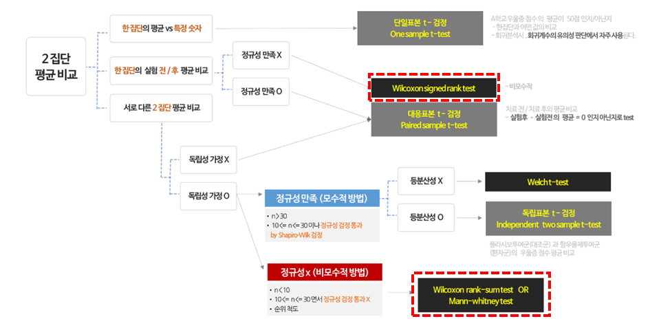

```python
import numpy as np
import pandas as pd
import matplotlib.pyplot as plt

# 정규성 검정
from scipy.stats import shapiro, anderson

# 비모수 검정
from scipy.stats import mannwhitneyu, ranksums, wilcoxon

# 등분산 검정
from scipy.stats import bartlett, fligner, levene

# 단일표본 t-검정
from scipy.stats import ttest_1samp

# 독립표본 t-검정
from scipy.stats import ttest_ind

# 대응표본 t-검정
from scipy.stats import ttest_rel

# 카이제곱 검정
from scipy.stats import chisquare, chi2_contingency, fisher_exact
```

## scipy 모듈

```
scipy
│
├── 01 integrate 수치적분, 미분방정식
│
├── 02 linalg (선형대수, 매트릭스 분해)
│
├── 03 optimize (방정식 해 구하는 알고리즘, 함수 최적화)
│
├── 04 signal (신호 관련)
│
├── 05 sparse (희소 행렬, 희소 선형 시스템)
│
└── 06 stats (통계 분석)
```

## scipy.stats 모듈

```python
from scipy import stats
print(f'Stats 하위 모듈 개수 : {len([x for x in dir(stats) if x[0] != "_"])}')
```

```
Stats 하위 모듈 개수 : 274
```

```
scipy.stats
│
├── 01 T-test
│   │
│   ├── ttest_1samp         (단일표본 t검정)
│   ├── ttest_ind           (독립표본 t검정)
│   └── ttest_rel           (대응표본 t검정)
│
├── 02 비모수 검정
│   │
│   ├── mannwhitneyu        (맨-휘트니 U 검정 - 중위수, 윌콕슨 순위합 검정과 동일하다 볼 수 있음)
│   ├── ranksums            (윌콕슨 순위합 검정 - 중위수)
│   └── wilcoxon            (윌콕슨 부호 순위 검정)
│
├── 03 정규정 검정
│   │
│   ├── anderson            (Anderson-Darling, 데이터 수가 상대적으로 많을 때)
│   ├── kstest              (Kolmogorov-Smirnov, 데이터 수가 상대적으로 많을 때)
│   ├── mstats.normaltest
│   └── shapiro             (shapiro, 정규분포 가장 엄격하게 검정, 데이터 수가 상대적으로 적을 때)
│
├── 04 등분산 검정
│   │
│   ├── bartlett
│   ├── fligner
│   └── levene
│
├── 05 카이제곱검정
│   │
│   ├── chisquare            (카이제곱검정, 적합도 검정)
│   ├── chi2_contingency     (카이제곱독립검정, 독립성 검정)
│   └── fisher_exact         (피셔 정확 검정 - 빈도수가 5개 이하 셀의 수가 전체 셀의 20%이상일 경우 사용)
│
└── 06 ANOVA (일원분산분석)
    │
    └── f_oneway (분산 분석은 statmodels 모듈이 더 좋음!)

> dir, help를 이용해서 파라미터들 찾아가며 사용하기
```

## 정규성 검정

- **다음 데이터의 정규성을 검증하라**
  - `shapiro` 검정시 **p-value = 0.34**이므로 유의수준 5%에서 귀무가설(“데이터는 정규성을 가진다”)을 기각할 수 없다.

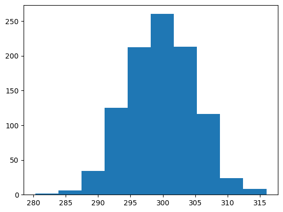

```
ShapiroResult(statistic=0.9981446862220764, pvalue=0.3485966622829437)
```

```python
df = pd.read_csv('https://raw.githubusercontent.com/Datamanim/datarepo/main/scipy/normal1.csv')
plt.hist(df)
plt.show()

print(shapiro(df))
```

- **다음 데이터의 정규성을 검증하라**
  - `shapiro` 검정시 **p-value = 2.3e-16** 이므로 유의수준 5%에서 귀무가설인 “데이터는 정규성을 가진다”를 기각하고 대립가설을 채택한다.
  - 즉, 데이터는 정규성을 가지지 않는다.

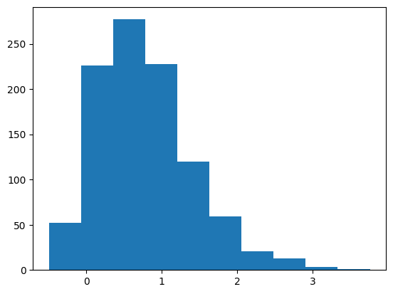

```
ShapiroResult(statistic=0.9578887224197388, pvalue=2.309859641255865e-16)
```

```python
df = pd.read_csv('https://raw.githubusercontent.com/Datamanim/datarepo/main/scipy/normal3.csv')
plt.hist(df)
plt.show()

print(shapiro(df))
```

- **위의 데이터를 log변환 한 후에 정규성을 가지는지 확인하라**
  - `shapiro` 검정시 **p-value = 0.17**이므로 유의수준 5%에서 귀무가설(“데이터는 정규성을 가진다”)을 기각할 수 없다.

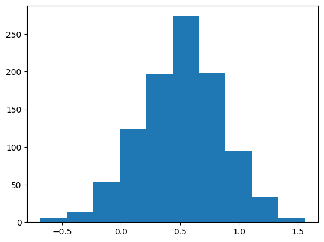

```python
df = pd.read_csv('https://raw.githubusercontent.com/Datamanim/datarepo/main/scipy/normal3.csv')
log_y_data = np.log1p(df)

plt.hist(log_y_data)
plt.show()

print(shapiro(log_y_data))
```

[output not shown]

- **다음 데이터의 정규성을 검증하라**
  - `shapiro` 검정시 **p-value = 0.15**이므로 유의수준 5%에서 귀무가설(“데이터는 정규성을 가진다”)을 기각할 수 없다.
  - 하지만 경고 메세지에서도 보이듯이 **5000개 초과의 샘플에 대해서는 샤피로 검정은 정확하지 않을 수 있다.**

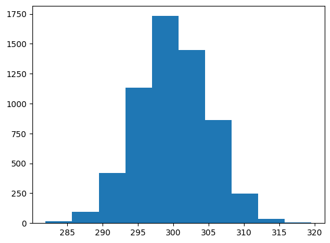

```
ShapiroResult(statistic=0.9995355606079102, pvalue=0.15070641040802002)
```

```
C:\Users\user\AppData\Roaming\Python\Python310\site-packages\scipy\stats\_morestats.py:1761: UserWarning: p-value may not be accurate for N > 5000.
  warnings.warn("p-value may not be accurate for N > 5000.")
```

```python
df = pd.read_csv('https://raw.githubusercontent.com/Datamanim/datarepo/main/scipy/normal6.csv')
plt.hist(df)
plt.show()

print(shapiro(df))
```

- `anderson` 검정을 실시
  - `anderson` 검정 결과의 [설명](https://docs.scipy.org/doc/scipy/reference/generated/scipy.stats.anderson.html)
  - *significance_level*는 유의확률값을 나타내며 *critical_values*는 각 유의확률값의 기준점이 된다.
  - 유의수준 5% 하에서 검정을 진행하려면 statistic값인 0.82이 **significance_level 이 5.에 위치한 인덱스를 critical_values 값에서 비교**하면 된다.
  - 즉, statistitc = 0.827이고 유의수준 5%에서 critical_values = 0.786을 가지므로 **귀무가설을 기각**하고 대립가설을 채택한다.
  - 따라서, 데이터는 **정규성을 가지지 않는다고 판단**한다. (p-value와 기각기준 부등호 개념이 반대)

```python
print(anderson(df['data'].values))
```

```
AndersonResult(statistic=0.8266993530414766, critical_values=array([0.576, 0.656, 0.786, 0.917, 1.091]), significance_level=array([15. , 10. ,  5. ,  2.5,  1. ]))
```

## 단일 표본 t-검정 (one-sample)

```python
df = pd.read_csv('https://raw.githubusercontent.com/Datamanim/datarepo/main/scipy/height1.csv')
```

[figure not shown]

```python
df = pd.read_csv('https://raw.githubusercontent.com/Datamanim/datarepo/main/scipy/height2.csv')
```

[figure not shown]

## 등분산 검정

```python
df = pd.read_csv('https://raw.githubusercontent.com/Datamanim/datarepo/main/scipy/scipy6.csv')

print(bartlett(df.A, df.B))
print(fligner(df.A, df.B))
print(levene(df.A, df.B))
```

```
BartlettResult(statistic=2.383217881104806, pvalue=0.12264468401742169)
FlignerResult(statistic=5.124831619122788, pvalue=0.023585858890699054)
LeveneResult(statistic=5.147914610463281, pvalue=0.023868975493455683)
```

## 독립표본 t-검정 (Independent)

- 독립 표본 t-검정의 경우 집단의 정규성에 따라 접근방식이 다르다.
- 정규성 검정은 `shapiro`, `anderson` (샘플 5000개 이상)을 통해 확인

**데이터가 정규성을 가지는 경우(모수적 검정)**  
> 두 집단의 등분산 검정을 한 후

```
from scipy.stats import ttest_ind
```

**데이터가 정규성을 가지지 않는 경우(비모수적 검정)**

- **두 개 학급의 시험성적에 대한 데이터이다. 두 학급의 시험 평균(비모수검정의 경우 중위값)은 동일하다 말할 수 있는지 확인하라**

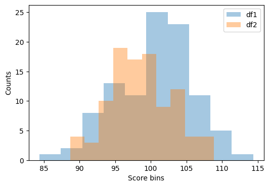

```python
df1 = pd.read_csv('https://raw.githubusercontent.com/Datamanim/datarepo/main/scipy/ind1.csv')
df2 = pd.read_csv('https://raw.githubusercontent.com/Datamanim/datarepo/main/scipy/ind2.csv')

plt.figure(figsize = (6, 4))
plt.hist(df1,label = 'df1',alpha = 0.4) ; plt.hist(df2,label = 'df2',alpha = 0.4)
plt.xlabel('Score bins') ; plt.ylabel('Counts') ; plt.legend()
plt.show()
```

```python
print(shapiro(df1))
print(shapiro(df2), '\n')

print(levene(df1['data'], df2['data']), '\n')

print(ttest_ind(df1, df2, equal_var = True))
```

```
ShapiroResult(statistic=0.9860947728157043, pvalue=0.37968069314956665)
ShapiroResult(statistic=0.990182638168335, pvalue=0.6793646216392517)

LeveneResult(statistic=2.5337683795339547, pvalue=0.11302904824469093)

Ttest_indResult(statistic=array([2.76719074]), pvalue=array([0.00619015]))
```

- **두 개 학급의 시험성적에 대한 데이터이다. 두 학급의 시험 평균(비모수검정의 경우 중위값)은 동일하다 말할 수 있는지 확인하라**

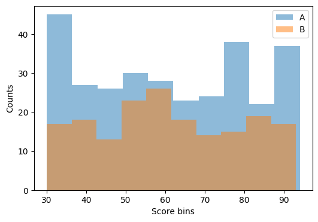

```python
df = pd.read_csv('https://raw.githubusercontent.com/Datamanim/datarepo/main/scipy/scipy5.csv')

plt.figure(figsize = (6, 4))
plt.hist(df['A'], alpha = 0.5, label = 'A') ; plt.hist(df['B'].dropna(), alpha = 0.5, label = 'B')
plt.xlabel('Score bins') ; plt.ylabel('Counts') ; plt.legend()
plt.show()
```

1. `shapiro` 검정을 통해 정규성 검정
   - `shapiro` 검정 결과 유의수준 5% 하에서 두 학급 모두 p-value < 0.05이므로 **귀무가설을 기각한다.** 즉, 정규성을 띄지 않는다.
   - 두 그룹 중 한 그룹만 정규성을 위배해도 독립표본 t-검정을 할 수 없다.
   - 따라서, 비모수 검정을 실시해야 한다.
2. `mannwhitneyu`, `ranksums` 검정을 통한 비모수 검정
   - `Mann-Whitney U Test` 검정 결과 p-value = 0.98으로 **귀무가설(평균은 같다)를 기각할 수 없다.** 두그룹의 평균은 동일하다 말할 수 있다.
   - `윌콕슨 순위합 검정(ranksums)`으로 확인해봐도 같은 결과가 나온다.

```python
print(shapiro(df['A']))
print(shapiro(df['B'].dropna()), '\n')

print(mannwhitneyu(df['A'], df['B'].dropna()))
print(ranksums(df['A'], df['B'].dropna()), '\n')
```

```
ShapiroResult(statistic=0.93753981590271, pvalue=6.175894240456614e-10)
ShapiroResult(statistic=0.9639444351196289, pvalue=0.00013572089665103704)

MannwhitneyuResult(statistic=27036.0, pvalue=0.9807458376150018)
RanksumsResult(statistic=0.02446942170858557, pvalue=0.9804781743503561)
```

- **두개 그룹에 대한 수치형 데이터이다. 두 그룹의 평균은 동일하다 말할 수 있는지 검정하라**

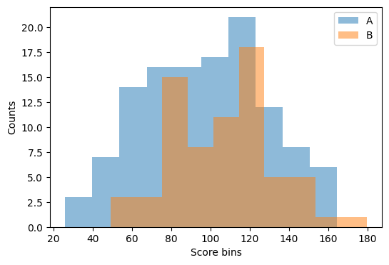

```python
df = pd.read_csv('https://raw.githubusercontent.com/Datamanim/datarepo/main/scipy/ind3.csv')

plt.figure(figsize = (6, 4))
plt.hist(df.loc[df['group'] == 'a', 'data'], label = 'A', alpha = 0.5)
plt.hist(df.loc[df['group'] == 'b', 'data'], label = 'B', alpha = 0.5)
plt.xlabel('Score bins') ; plt.ylabel('Counts') ; plt.legend()
plt.show()
```

1. `shapiro` 검정을 통한 정규성 검정
   - `shapiro` 검정 결과 두 그룹 모두 유의수준 5% 하에서 p-value > 0.05이므로 귀무가설을 채택한다. 즉, 정규성을 가진다.
2. `levene` 검정을 통한 등분산 검정
   - `levene` 검정 결과 유의수준 5% 하에서 p-value = 0.014 < 0.05이므로 귀무가설을 기각한다. 즉, 두 그룹은 등분산이 아니다.
3. `ttest_ind` 검정을 통한 독립표본 t-검정
   - 두 학급이 등분산이 아니므로 `eqaul_var = False`로 설정하여 t-test를 진행
   - `ttest_ind` 검정 결과 p-value = 0.029 < 0.05이므로 유의수준 5% 하에서 귀무가설을 기각한다. 즉, 두 그룹의 평균은 동일하지 않다.

```python
a = df.loc[df['group'] == 'a', 'data']
b = df.loc[df['group'] == 'b', 'data']

print(shapiro(a))
print(shapiro(b), '\n')

print(levene(a, b), '\n')

print(ttest_ind(a, b, equal_var = False))
```

```
ShapiroResult(statistic=0.9834123253822327, pvalue=0.1473984718322754)
ShapiroResult(statistic=0.9831849336624146, pvalue=0.47018250823020935)

LeveneResult(statistic=6.185601018015722, pvalue=0.013750484571911342)

Ttest_indResult(statistic=-2.1949470315829265, pvalue=0.029512802991767915)
```

- **두개 그룹에 대한 수치형 데이터이다. 두 그룹의 평균은 동일하다 말할 수 있는지 검정하라**

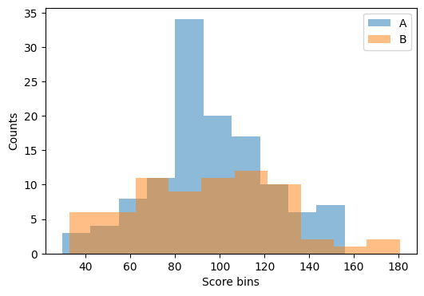

```python
df = pd.read_csv('https://raw.githubusercontent.com/Datamanim/datarepo/main/scipy/ind6.csv')

plt.figure(figsize = (6, 4))
plt.hist(df['a'], label = 'A', alpha = 0.5) ; plt.hist(df['b'], label = 'B', alpha = 0.5)
plt.xlabel('Score bins') ; plt.ylabel('Counts') ; plt.legend()
plt.show()
```

1. `shapiro` 검정을 통한 정규성 검정
   - `shapiro` 검정 결과 두 그룹 모두 유의수준 5% 하에서 p-value > 0.05이므로 귀무가설을 채택한다. 즉, 정규성을 가진다.
2. `levene` 검정을 통한 등분산 검정
   - `levene` 검정 결과 유의수준 5% 하에서 p-value = 0.047 < 0.05이므로 귀무가설을 기각한다. 즉, 두 그룹은 등분산이 아니다.
3. `ttest_ind` 검정을 통한 독립표본 t-검정
   - 두 학급이 등분산이 아니므로 `eqaul_var = False`로 설정하여 t-test를 진행
   - `ttest_ind` 검정 결과 p-value = 0.998 > 0.05이므로 유의수준 5% 하에서 귀무가설을 채택한다. 즉, 두 그룹의 평균은 동일하다.

```python
a = df['a'].dropna()
b = df['b'].dropna()

print(shapiro(a))
print(shapiro(b), '\n')

print(levene(a, b), '\n')

print(ttest_ind(a, b, equal_var = False))
```

```
ShapiroResult(statistic=0.9865895509719849, pvalue=0.28390026092529297)
ShapiroResult(statistic=0.9854329228401184, pvalue=0.5937777757644653)

LeveneResult(statistic=3.9862856894158347, pvalue=0.04731495612868527)

Ttest_indResult(statistic=0.0015963310698567188, pvalue=0.9987289046092704)
```

## 대응표본 t-검정 (paired)

- **특정 질병 집단의 투약 전후의 혈류량 변화를 나타낸 데이터이다. 투약 전후의 변화가 있는지 검정하라**

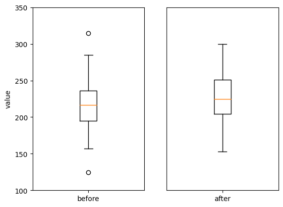

```python
df = pd.read_csv('https://raw.githubusercontent.com/Datamanim/datarepo/main/scipy/rel2.csv')

plt.figure(figsize = (6, 4))
fig, ax = plt.subplots(1, 2)

ax[0].boxplot(df['before'])
ax[0].set_xticklabels(['before'])
ax[0].set_ylim(100, 350)
ax[0].set_ylabel('value')

ax[1].boxplot(df['after'])
ax[1].set_xticklabels(['after'])
ax[1].set_ylim(100, 350)
ax[1].get_yaxis().set_visible(False)

plt.show()
```

1. `shapiro` 검정을 통한 정규성 검정
   - `shapiro` 검정 결과 두 그룹 모두 유의수준 5% 하에서 p-value > 0.05이므로 귀무가설을 채택한다. 즉, 정규성을 가진다.
2. `levene` 검정을 통한 등분산 검정
   - `levene` 검정 결과 유의수준 5% 하에서 p-value = 0.800 > 0.05이므로 귀무가설을 채택한다. 즉, 두 그룹은 등분산이다.
3. `ttest_rel` 검정을 통한 대응표본 t-검정
   - 대응표본의 경우 등분산이여도 따로 지정해줄 변수가 없다.
   - `ttest_rel` 검정 결과 p-value = 0.012 < 0.05이므로 유의수준 5% 하에서 귀무가설을 기각한다. 즉, 투약 효과가 있다.

```python
before = df['before']
after = df['after']
print(shapiro(before))
print(shapiro(after), '\n')

print(levene(before, after), '\n')

print(ttest_rel(before, after, alternative = 'two-sided'))
```

```
ShapiroResult(statistic=0.9907894134521484, pvalue=0.6065712571144104)
ShapiroResult(statistic=0.9916958808898926, pvalue=0.6923439502716064)

LeveneResult(statistic=0.06427968690211128, pvalue=0.8000741651677987)

Ttest_relResult(statistic=-2.5535473487670677, pvalue=0.011926744724546513)
```

- **특정 질병 집단의 투약 전후의 혈류량 변화를 나타낸 데이터이다. 투약 전후의 변화가 있는지 검정하라**

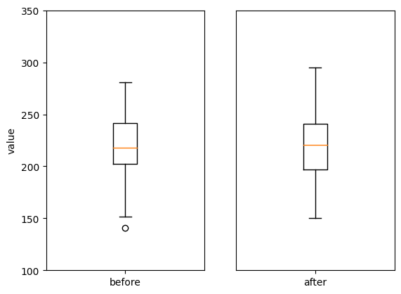

```python
df = pd.read_csv('https://raw.githubusercontent.com/Datamanim/datarepo/main/scipy/rel3.csv')

plt.figure(figsize = (6, 4))
fig, ax = plt.subplots(1, 2)

ax[0].boxplot(df['before'])
ax[0].set_xticklabels(['before'])
ax[0].set_ylim(100, 350)
ax[0].set_ylabel('value')

ax[1].boxplot(df['after'])
ax[1].set_xticklabels(['after'])
ax[1].set_ylim(100, 350)
ax[1].get_yaxis().set_visible(False)

plt.show()
```

1. `shapiro` 검정을 통한 정규성 검정
   - `shapiro` 검정 결과 두 그룹 모두 유의수준 5% 하에서 p-value > 0.05이므로 귀무가설을 채택한다. 즉, 정규성을 가진다.
2. `levene` 검정을 통한 등분산 검정
   - `levene` 검정 결과 유의수준 5% 하에서 p-value = 0.247 > 0.05이므로 귀무가설을 채택한다. 즉, 두 그룹은 등분산이다.
3. `ttest_rel` 검정을 통한 대응표본 t-검정
   - 대응표본의 경우 등분산이여도 따로 지정해줄 변수가 없다.
   - `ttest_rel` 검정 결과 p-value = 0.850 > 0.05이므로 유의수준 5% 하에서 귀무가설을 채택한다. 즉, 투약 효과가 없다.

```python
before = df['before']
after = df['after']
print(shapiro(before))
print(shapiro(after), '\n')

print(levene(before, after), '\n')

print(ttest_rel(before, after, alternative = 'two-sided'))
```

```
ShapiroResult(statistic=0.9920635223388672, pvalue=0.7270597219467163)
ShapiroResult(statistic=0.992019534111023, pvalue=0.7229286432266235)

LeveneResult(statistic=1.3463330638203617, pvalue=0.24708279045237214)

Ttest_relResult(statistic=0.188900575991026, pvalue=0.8504925317234707)
```

- **특정 집단의 학습 전후 시험 성적 변화를 나타낸 데이터이다. 시험 전과 후에 차이가 있는지 검정하라**

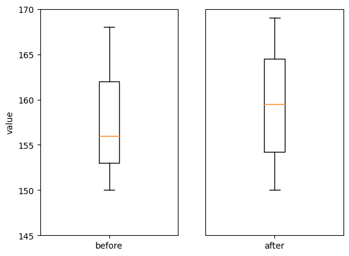

```python
df = pd.read_csv('https://raw.githubusercontent.com/Datamanim/datarepo/main/scipy/rel1.csv')

plt.figure(figsize = (6, 4))
fig, ax = plt.subplots(1, 2)

ax[0].boxplot(df['before'])
ax[0].set_xticklabels(['before'])
ax[0].set_ylim(145, 170)
ax[0].set_ylabel('value')

ax[1].boxplot(df['after'])
ax[1].set_xticklabels(['after'])
ax[1].set_ylim(145, 170)
ax[1].get_yaxis().set_visible(False)

plt.show()
```

1. `shapiro` 검정을 통한 정규성 검정
   - `shapiro` 검정 결과 두 그룹 모두 유의수준 5% 하에서 p-value < 0.05이므로 귀무가설을 기각한다. 즉, 정규성을 띄지 않는다.
2. `levene` 검정을 통한 등분산 검정
   - `levene` 검정 결과 유의수준 5% 하에서 p-value = 0.706 > 0.05이므로 귀무가설을 채택한다. 즉, 두 그룹은 등분산이다.
3. `wilcoxon` 검정을 통한 부호 순위 검정
   - 두 그룹 모두 정규성을 띄지 않기 때문에 비모수 검정 시행
   - `wilcoxon` 검정 결과 p-value = 0.121 > 0.05이므로 귀무가설을 채택한다. 즉, 시험 성적의 변화는 없다.

```python
before = df['before']
after = df['after']
print(shapiro(before))
print(shapiro(after), '\n')

print(levene(before, after), '\n')

print(wilcoxon(before, after))
```

```
ShapiroResult(statistic=0.9173726439476013, pvalue=0.001897332607768476)
ShapiroResult(statistic=0.9448971152305603, pvalue=0.021141061559319496)

LeveneResult(statistic=0.14329522146179022, pvalue=0.7058456563194881)

WilcoxonResult(statistic=437.0, pvalue=0.12098409484052809)
```

- **한 기계 부품의 rpm 수치를 두가지 다른 상황에서 측정했다. (총 70세트) b 상황이 a 상황보다 rpm 값이 높다고 말할 수 있는지 검정하라**

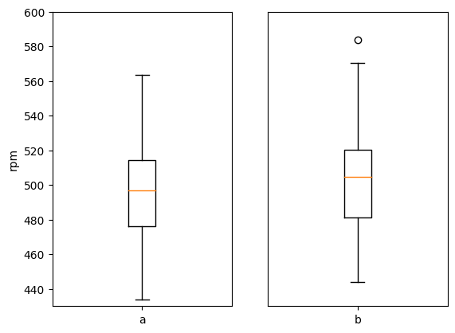

```python
df = pd.read_csv('https://raw.githubusercontent.com/Datamanim/datarepo/main/scipy/rel4.csv')

plt.figure(figsize = (6, 4))
fig ,ax = plt.subplots(1, 2)

ax[0].boxplot(df.loc[df['group'] == 'a', 'rpm'])
ax[0].set_xticklabels(['a'])
ax[0].set_ylim(430, 600)
ax[0].set_ylabel('rpm')

ax[1].boxplot(df.loc[df['group'] == 'b', 'rpm'])
ax[1].set_xticklabels(['b'])
ax[1].set_ylim(430, 600)
ax[1].get_yaxis().set_visible(False)

plt.show()
```

```python
a = df.loc[df['group'] == 'a', 'rpm']
b = df.loc[df['group'] == 'b', 'rpm']

print(shapiro(a))
print(shapiro(b), '\n')

print(levene(a, b), '\n')

print(ttest_rel(a, b, alternative = 'greater'))
```

```
ShapiroResult(statistic=0.9907213449478149, pvalue=0.8884111046791077)
ShapiroResult(statistic=0.984674870967865, pvalue=0.5505106449127197)

LeveneResult(statistic=0.06716114122680159, pvalue=0.7959020864923277)

Ttest_relResult(statistic=-1.9018108294460812, pvalue=0.9693143365355352)
```

## 카이제곱 검정 (교차분석)

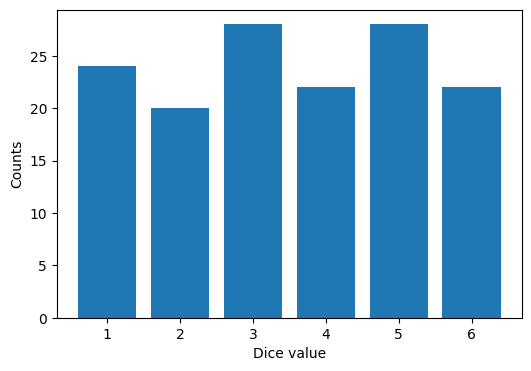

```python
df = pd.read_csv('https://raw.githubusercontent.com/Datamanim/datarepo/main/scipy/dice.csv')

plt.figure(figsize = (6, 4))
plt.bar(df['dice_number'], df['counts'])
plt.xlabel('Dice value') ; plt.ylabel('Counts')
plt.show()
```

```python
df = pd.read_csv('https://raw.githubusercontent.com/Datamanim/datarepo/main/scipy/hands2.csv')

target = df['hands'].value_counts().to_frame().reset_index()
target['expected'] = [int(target['count'].sum() * 0.8), int(target['count'].sum() * 0.2)]
display(target)

print(chisquare(target['count'], target['expected']))
```

|  | hands | count | expected |
| --- | --- | --- | --- |
| 0 | right | 420 | 400 |
| 1 | left | 80 | 100 |

```
Power_divergenceResult(statistic=5.0, pvalue=0.025347318677468325)
```

```python
df = pd.read_csv('https://raw.githubusercontent.com/Datamanim/datarepo/main/body/body.csv')
df.head()
```

|  | 측정나이 | 측정회원성별 | 신장 : cm | 체중 : kg | 체지방율 : % | 이완기혈압(최저) : mmHg | 수축기혈압(최고) : mmHg | 악력D : kg | 앉아윗몸앞으로굽히기 : cm | 교차윗몸일으키기 : 회 | 제자리 멀리뛰기 : cm | 등급 |
| --- | --- | --- | --- | --- | --- | --- | --- | --- | --- | --- | --- | --- |
| 0 | 59.0 | M | 175.0 | 70.6 | 19.2 | 91.0 | 150.0 | 40.6 | 12.2 | 30.0 | 179.0 | C |
| 1 | 40.0 | F | 161.4 | 45.8 | 21.7 | 62.0 | 119.0 | 22.1 | 16.0 | 32.0 | 165.0 | B |
| 2 | 27.0 | M | 176.6 | 84.8 | 19.2 | 87.0 | 153.0 | 45.9 | 13.2 | 61.0 | 216.0 | B |
| 3 | 38.0 | M | 167.6 | 76.7 | 24.7 | 63.0 | 132.0 | 43.6 | 16.0 | 45.0 | 231.0 | A |
| 4 | 21.0 | M | 165.2 | 66.2 | 21.5 | 83.0 | 106.0 | 33.5 | 10.6 | 46.0 | 198.0 | C |

```python
cdf = pd.crosstab(df['측정회원성별'], df['등급'])
display(cdf)
```

| 등급 측정회원성별 | A | B | C | D |
| --- | --- | --- | --- | --- |
| F | 1484 | 1130 | 1147 | 1120 |
| M | 1865 | 2219 | 2202 | 2229 |

```python
df = pd.read_csv('https://raw.githubusercontent.com/Datamanim/datarepo/main/scipy/fe2.csv', index_col = 0)
cdf = df.iloc[:-1, :-1]
display(cdf)
```

|  | 불참 | 참석 |
| --- | --- | --- |
| 남성 | 4 | 2 |
| 여성 | 1 | 9 |